# eFP-Seq Browser

7-day-old, plate-grown, long-day-grown seedling

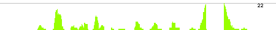

[figure not shown]

0.28021

[figure not shown]

10dayOldSeedling

2.42899

Col-0 repl1, SRA: SRS351292  
[NCBI SRA](http://www.ncbi.nlm.nih.gov/Traces/sra/?run=SRR527164); [PubLink](http://bar.utoronto.ca/~dev/eFP-Seq_Browser/undefined)  
More Details

7-day-old, plate-grown, long-day-grown seedling

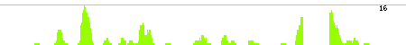

[figure not shown]

0.28609

[figure not shown]

10dayOldSeedling

1.82861

Col-0 repl2, SRA: SRS351293  
[NCBI SRA](http://www.ncbi.nlm.nih.gov/Traces/sra/?run=SRR527165); [PubLink](http://bar.utoronto.ca/~dev/eFP-Seq_Browser/undefined)  
More Details

11-day-old light-grown plate-grown seedling

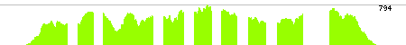

[figure not shown]

0.63336

[figure not shown]

10dayOldSeedling

127.73062

seedling, GSM1017156, SRA: SRS367537  
[NCBI SRA](http://www.ncbi.nlm.nih.gov/Traces/sra/?run=SRR584115); [PubLink](http://www.ncbi.nlm.nih.gov/pmc/articles/PMC3877825)  
More Details

11-day-old light-grown plate-grown seedling

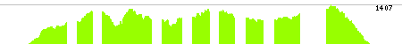

[figure not shown]

0.62049

[figure not shown]

10dayOldSeedling

132.73246

seedling, GSM1017162, SRA: SRS367543  
[NCBI SRA](http://www.ncbi.nlm.nih.gov/Traces/sra/?run=SRR584121); [PubLink](http://www.ncbi.nlm.nih.gov/pmc/articles/PMC3877825)  
More Details

11-day-old light-grown plate-grown seedling

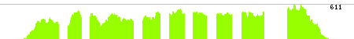

[figure not shown]

0.63771

[figure not shown]

10dayOldSeedling

68.67883

seedlings, GSM1017170, SRA: SRS367551  
[NCBI SRA](http://www.ncbi.nlm.nih.gov/Traces/sra/?run=SRR584129); [PubLink](http://www.ncbi.nlm.nih.gov/pubmed/23192226)  
More Details

11-day-old light-grown plate-grown seedling

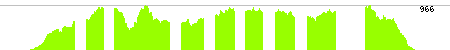

[figure not shown]

0.61891

[figure not shown]

10dayOldSeedling

101.6771

seedlings, GSM1017175, SRA: SRS367556  
[NCBI SRA](http://www.ncbi.nlm.nih.gov/Traces/sra/?run=SRR584134); [PubLink](http://www.ncbi.nlm.nih.gov/pubmed/23192226)  
More Details

9 day-old 24h-light-grown seedling

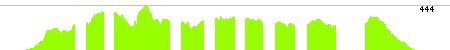

[figure not shown]

0.62164

[figure not shown]

10dayOldSeedling

111.81256

LL, WT rep 1, GSM1072464, SRA: SRS388017  
[NCBI SRA](http://www.ncbi.nlm.nih.gov/Traces/sra/?run=SRR653555); [PubLink](http://www.ncbi.nlm.nih.gov/pubmed/23818596)  
More Details

9 day-old 24h-light-grown seedling

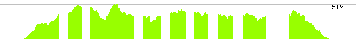

[figure not shown]

0.62409

[figure not shown]

10dayOldSeedling

116.72248

LL, WT rep 2, GSM1072465, SRA: SRS388018  
[NCBI SRA](http://www.ncbi.nlm.nih.gov/Traces/sra/?run=SRR653556); [PubLink](http://www.ncbi.nlm.nih.gov/pubmed/23818596)  
More Details

9 day-old 24h-light-grown seedling

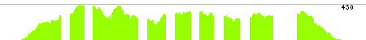

[figure not shown]

0.62792

[figure not shown]

10dayOldSeedling

117.95304

LL, WT rep 3, GSM1072466, SRA: SRS388019  
[NCBI SRA](http://www.ncbi.nlm.nih.gov/Traces/sra/?run=SRR653557); [PubLink](http://www.ncbi.nlm.nih.gov/pubmed/23818596)  
More Details

9 day-old long-day-grown seedling harvested 2h after light on on the 9th day

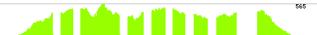

[figure not shown]

0.61376

[figure not shown]

10dayOldSeedling

198.76836

Long days WT, ZT2, rep 1, GSM1072470, SRA: SRS388023  
[NCBI SRA](http://www.ncbi.nlm.nih.gov/Traces/sra/?run=SRR653561); [PubLink](http://www.ncbi.nlm.nih.gov/pubmed/23818596)  
More Details

9 day-old long-day-grown seedling harvested 2h after light on on the 9th day

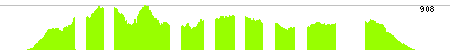

[figure not shown]

0.61222

[figure not shown]

10dayOldSeedling

198.66926

Long days WT, ZT2, rep 2, GSM1072471, SRA: SRS388024  
[NCBI SRA](http://www.ncbi.nlm.nih.gov/Traces/sra/?run=SRR653562); [PubLink](http://www.ncbi.nlm.nih.gov/pubmed/23818596)  
More Details

9 day-old long-day-grown seedling harvested 2h after light on on the 9th day

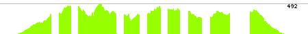

[figure not shown]

0.60421

[figure not shown]

10dayOldSeedling